# Analysis of EA NHL Results

December 06, 2017

\[ \newcommand{\Prob}{\operatorname{P}} \newcommand{\E}{\operatorname{E}} \newcommand{\Var}{\operatorname{Var}} \newcommand{\Cov}{\operatorname{Cov}} \newcommand{\se}{\operatorname{se}} \newcommand{\re}{\operatorname{re}} \newcommand{\ybar}{{\overline{Y}}} \newcommand{\phat}{{\hat{p}}} \newcommand{\that}{{\hat{T}}} \newcommand{\med}{{\tilde{Y}}} \newcommand{\Logit}{{\operatorname{Logit}}} \]

## Introduction

## Data

- 217 Games Played
- EA NHL 12, 13, and 17
- Tim \(\rightarrow\) P1
- Randy \(\rightarrow\) P2

## Explanatory Variables

- Categorical:
  - Home vs. Away
  - Scored First
- Discrete:
  - Shots
  - Hits
  - Penalty Minutes (PM)
  - Penalty Shots
  - Breakaways
  - Powerplays
  - Faceoffs Won
  - Offensive Faceoffs Won
- Continuous:
  - Time of Attack (ToA)
  - Passing %

## Research Question

What periphery (non-goal related) statistics can be used to predict the outcome of a hockey game?

## Exploratory Analysis

## Game Results

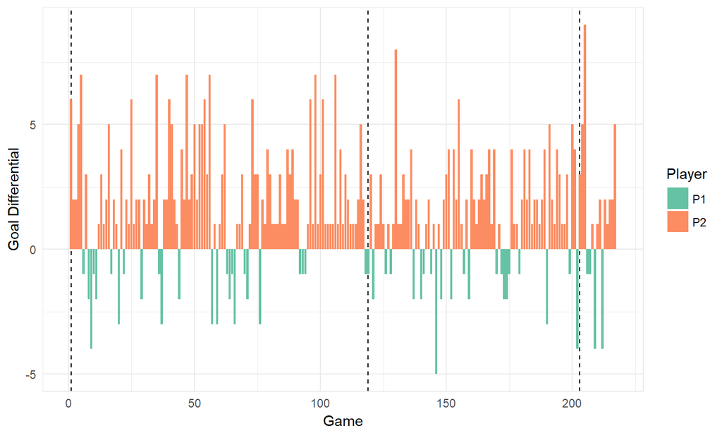

## Correlation Matrix

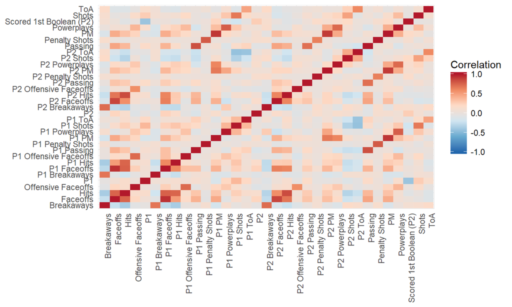

## Distribution of Goals

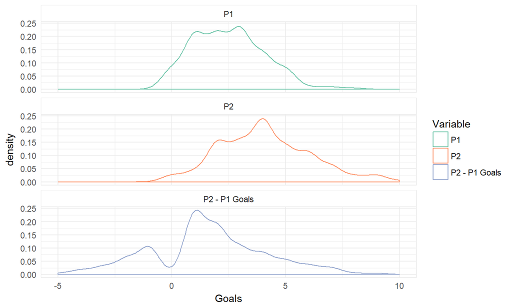

## Goal Distribution by Version

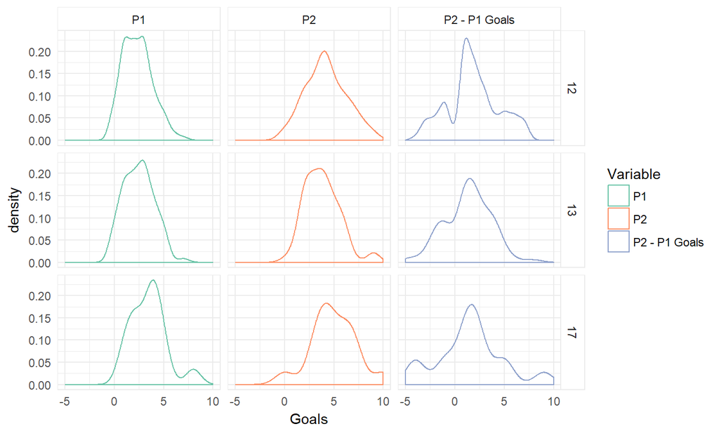

## Goals vs. Shots

> "You miss 100% of the shots you don't take." - Wayne Gretzky

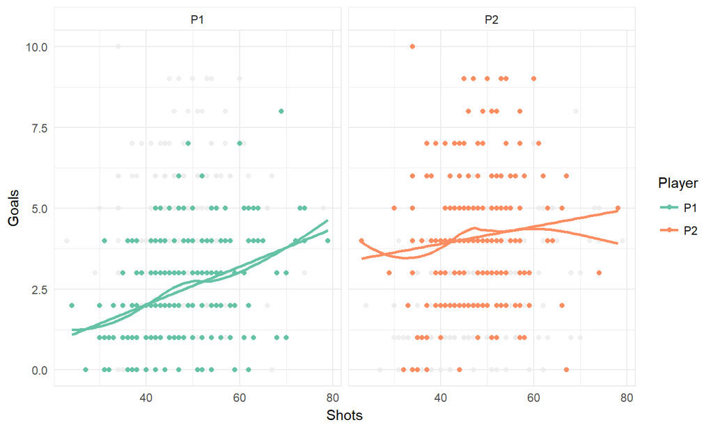

## Autocorrelation

Autocorrelation measures the correlation between \(\left(X_{t-k}, X_{t}\right), t=k, k+1\dots,n\). It is primarily used in timeseries analysis to measure the tendency for a time series to be mean reverting (negative autocorrelation) or a tendency to go on long runs in one direct or the other (positive autocorrelation). This is primarily used in the analysis of stock returns, but can be applied to any time series.

## Autocorrelation Plot

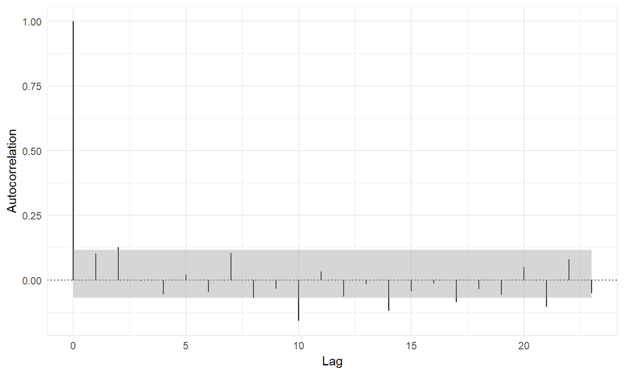

## Autocorrelation Model

\[ \operatorname{Logit}\left( \text{P1 Wins} \right) = \alpha + \beta_{1}\text{Previous Game's Result} \]

```
##
## Call:
## glm(formula = `P1 Win` ~ `P1 Previous Game`, family = binomial,
##     data = .)
##
## Deviance Residuals:
##     Min       1Q   Median       3Q      Max
## -0.8677  -0.6905  -0.6905  -0.6905   1.7610
##
## Coefficients:
##                       Estimate Std. Error z value Pr(>|z|)
## (Intercept)            -1.3122     0.1904  -6.891 5.55e-12 ***
## `P1 Previous Game`Yes   0.5294     0.3568   1.484    0.138
## ---
## Signif. codes:  0 '***' 0.001 '**' 0.01 '*' 0.05 '.' 0.1 ' ' 1
##
## (Dispersion parameter for binomial family taken to be 1)
##
##     Null deviance: 236.11  on 215  degrees of freedom
## Residual deviance: 233.98  on 214  degrees of freedom
##   (1 observation deleted due to missingness)
## AIC: 237.98
##
## Number of Fisher Scoring iterations: 4
```

## Durbin-Watson Test

\[ H_{0}: \text{Autocorrelation} = 0 \] \[ H_{1}: \text{Autocorrelation} \neq 0 \]

```
##
##  Durbin-Watson test
##
## data:  hockey_acf_logit
## DW = 2.024, p-value = 0.8647
## alternative hypothesis: true autocorrelation is not 0
```

## Modeling

## Contingency Table Model

```
## , , Home = P1
##
##           Winner
## Scored_1st P1 P2
##         P1 12 12
##         P2  4 23
##
## , , Home = P2
##
##           Winner
## Scored_1st P1 P2
##         P1 25 35
##         P2 10 96
```

## flatten_ct

| Scored_1st | Winner | Home |
| --- | --- | --- |
| P1 | P1 | P1 |
| P1 | P1 | P1 |
| P1 | P1 | P1 |
| P1 | P1 | P1 |
| P1 | P1 | P1 |
| P1 | P1 | P1 |

| Scored_1st | Winner | Home | n |
| --- | --- | --- | --- |
| P1 | P1 | P1 | 12 |
| P1 | P1 | P2 | 25 |
| P1 | P2 | P1 | 12 |
| P1 | P2 | P2 | 35 |
| P2 | P1 | P1 | 4 |
| P2 | P1 | P2 | 10 |
| P2 | P2 | P1 | 23 |
| P2 | P2 | P2 | 96 |

## Regression Models and Goodness of Fit Tests

### Logit Model

\[ \operatorname{Logit}\left( \text{P1 Wins} \right) = \alpha + \beta_{1}\text{Scored First} + \beta_{2}\text{Home Team} \]

### Log Linear Model

\[ \ln(\mu) = \alpha + \beta_{1}\text{Scored First} + \beta_{2}\text{P1 Wins} + \beta_{3}\text{Home Team} \]

## Regression Models and Goodness of Fit Tests Outputs

```
##  (Intercept) Scored_1stP2       HomeP2
##  -0.04539605   1.87687764   0.40057197
```

```
##
## Chi-squared Goodness of Fit Test
##
## model: hockey_ct_logit
## Chi-squared = 0.04855, df = 1, p-value = 0.82561
```

```
##
## G-squared Goodness of Fit Test
##
## model: hockey_ct_logit
## G-squared = 0.04815, df = 1, p-value = 0.82632
```

## Log Linear Models and Goodness of Fit Tests Outputs

```
##           (Intercept)          Scored_1stP2              WinnerP2
##            2.50734710           -1.19156361           -0.04539606
##                HomeP2 Scored_1stP2:WinnerP2   Scored_1stP2:HomeP2
##            0.70057578            1.87687765            0.31309456
##       WinnerP2:HomeP2
##            0.40057197
```

```
##
## Chi-squared Goodness of Fit Test
##
## model: hockey_ct_loglin
## Chi-squared = 0.04855, df = 1, p-value = 0.82561
```

```
##
## G-squared Goodness of Fit Test
##
## model: hockey_ct_loglin
## G-squared = 0.04815, df = 1, p-value = 0.82632
```

## Full Model

```
##             (Intercept)          `Scored 1st`P2              `P1 Shots`
##            -9.882439877            -1.964100240             0.013922296
##              `P2 Shots`               `P1 Hits`               `P2 Hits`
##            -0.016037708            -0.007771521             0.043845796
##                `P1 ToA`                `P2 ToA`            `P1 Passing`
##            -0.209459372            -0.052092628             8.197579923
##            `P2 Passing`           `P1 Faceoffs`           `P2 Faceoffs`
##             9.170534901            -0.061719701            -0.066995303
## `P1 Offensive Faceoffs` `P2 Offensive Faceoffs`                 `P1 PM`
##             0.072268107             0.071543085             0.050668097
##                 `P2 PM`         `P1 Powerplays`         `P2 Powerplays`
##             0.005239128             0.249659414            -0.066562314
##      `P1 Penalty Shots`      `P2 Penalty Shots`         `P1 Breakaways`
##             0.226441915            -1.324943617             0.227003485
##         `P2 Breakaways`
##            -0.041275380
```

## Backward BIC

\[ \operatorname{Logit}\left( \text{P1 Wins} \right) = \alpha + \beta_{1}\text{Scored 1st} + \beta_{2}\text{P1 Powerplays} \] \[ + \beta_{3}\text{P2 Penalty Shots} \] \[ = -0.8114 - 1.7359\text{Scored 1st} + 0.2133\text{P1 Powerplays} \] \[ - 1.5155\text{P2 Penalty Shots} \] Where: \[ \text{Scored 1st} = \begin{cases} 0,\text{ if P1} \\ 1,\text{ if P2} \end{cases} \]

```
##                         2.5 %    97.5 %
## (Intercept)        0.21242841 0.9011030
## `Scored 1st`P2     0.08355758 0.3556937
## `P1 Powerplays`    1.04004592 1.4827889
## `P2 Penalty Shots` 0.03360702 0.8073160
```

## LASSO

## LASSO Plot

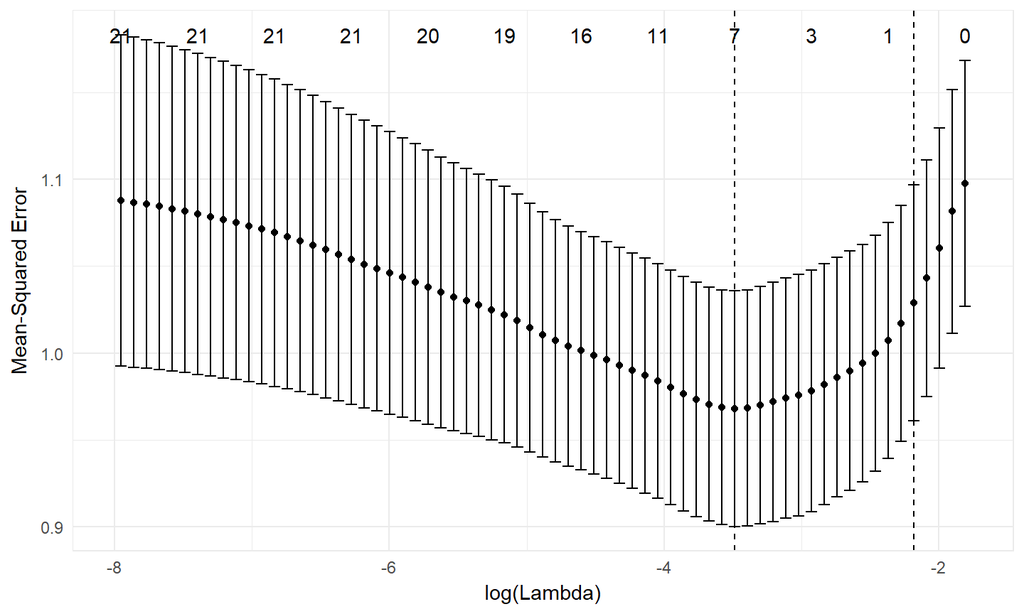

## LASSO Coefficients 1se

```
## 22 x 1 sparse Matrix of class "dgCMatrix"
##                                  1
## (Intercept)             -0.8527071
## Scored 1st Boolean (P2) -0.5670376
## P1 Shots                 .
## P2 Shots                 .
## P1 Hits                  .
## P2 Hits                  .
## P1 ToA                   .
## P2 ToA                   .
## P1 Passing               .
## P2 Passing               .
## P1 PM                    .
## P2 PM                    .
## P1 Powerplays            .
## P2 Powerplays            .
## P1 Faceoffs              .
## P2 Faceoffs              .
## P1 Breakaways            .
## P2 Breakaways            .
## P1 Penalty Shots         .
## P2 Penalty Shots         .
## P1 Offensive Faceoffs    .
## P2 Offensive Faceoffs    .
```

## LASSO Coefficients Min

```
## 22 x 1 sparse Matrix of class "dgCMatrix"
##                                    1
## (Intercept)             -2.103339281
## Scored 1st Boolean (P2) -1.398137226
## P1 Shots                 0.004405199
## P2 Shots                 .
## P1 Hits                  .
## P2 Hits                  .
## P1 ToA                   .
## P2 ToA                   .
## P1 Passing               0.903758203
## P2 Passing               0.990987539
## P1 PM                    .
## P2 PM                    .
## P1 Powerplays            0.116633884
## P2 Powerplays            .
## P1 Faceoffs              .
## P2 Faceoffs              .
## P1 Breakaways            0.056989459
## P2 Breakaways            .
## P1 Penalty Shots         .
## P2 Penalty Shots        -0.497227038
## P1 Offensive Faceoffs    .
## P2 Offensive Faceoffs    .
```

## LASSO Average Coefficient

```
##             (Intercept) Scored 1st Boolean (P2)                P1 Shots
##           -2.343864e+00           -1.413696e+00            4.576515e-03
##                P2 Shots                 P1 Hits                 P2 Hits
##           -2.228331e-05            0.000000e+00            0.000000e+00
##                  P1 ToA                  P2 ToA              P1 Passing
##            0.000000e+00            0.000000e+00            1.073199e+00
##              P2 Passing                   P1 PM                   P2 PM
##            1.215923e+00            0.000000e+00            5.687496e-05
##           P1 Powerplays           P2 Powerplays             P1 Faceoffs
##            1.217150e-01            0.000000e+00           -1.352674e-04
##             P2 Faceoffs           P1 Breakaways           P2 Breakaways
##            0.000000e+00            6.276038e-02            0.000000e+00
##        P1 Penalty Shots        P2 Penalty Shots   P1 Offensive Faceoffs
##            0.000000e+00           -5.293945e-01            2.589165e-05
##   P2 Offensive Faceoffs
##            0.000000e+00
```

## LASSO Average Lambda

```
## 22 x 1 sparse Matrix of class "dgCMatrix"
##                                    1
## (Intercept)             -2.291872149
## Scored 1st Boolean (P2) -1.411379910
## P1 Shots                 0.004591247
## P2 Shots                 .
## P1 Hits                  .
## P2 Hits                  .
## P1 ToA                   .
## P2 ToA                   .
## P1 Passing               1.033854992
## P2 Passing               1.158818635
## P1 PM                    .
## P2 PM                    .
## P1 Powerplays            0.121235931
## P2 Powerplays            .
## P1 Faceoffs              .
## P2 Faceoffs              .
## P1 Breakaways            0.062261956
## P2 Breakaways            .
## P1 Penalty Shots         .
## P2 Penalty Shots        -0.525402691
## P1 Offensive Faceoffs    .
## P2 Offensive Faceoffs    .
```

## Results

## Model

- LASSO Average Lambda chosen
  - Scored First
  - P1 Shots
  - P1 & P2 Passing
  - P1 Powerplays
  - P1 Breakaways
  - P2 Penalty Shots

\[ \ln\left( \frac{\text{P1 Wins}}{\text{P2 Wins}} \right) = -2.2919 - 1.4114\text{Scored First} + 0.0046\text{P1 Shots} \] \[ + 1.0339\text{P1 Passing} + 1.1588\text{P2 Passing} + 0.1212\text{P1 Powerplays} \] \[ + 0.0623\text{P1 Breakaways} - 0.5254\text{P2 Penalty Shots} \]

## Interpretation

- By scoring first, a player increases their estimated odds in favour of winning by a multiplicative factor of 4.1016
- Only P1's shots was found as a useful predictive measure.
  - Increases the estimated odds in favour by a multiplicative factor of 1.0046 per each additional shot
  - So not a lot
- If both players make a lot of their passes, P1's increases their estimated odds in favour of winning by a multiplicative factor of:
  - P1: 2.8119
  - P2: 3.1862
- The more 1-on-0 opportunities given up in a game by a player, the less likely that player will win.
  - Breakaways: 1.0642
  - Penalty Shots: 0.5913

## Weaknesses

- Based on a video game
  - May not apply to real life
- Who is P1 in real life?
  - Other combinations of players may have different results
- Includes P1's and P2's Passing %
  - Both have the same sign
  - Unexpected
- Possible overfitting
  - Uses \(\lambda_{Min}\) instead of \(\lambda_{1se}\)
- Introduced bias to lower variance
- It may be beneficial to use the average coefficient LASSO, with a cutoff if the variable appears in \(<x\%\) of results

## References

Gelman, A. (2014, June 02). Why we hate stepwise regression. Retrieved November 29, 2017, from http://andrewgelman.com/2014/06/02/hate-stepwise-regression/

Hastie, T., & Qian, J. (2014, June 26). Glmnet Vignette. Retrieved November 29, 2017, from https://web.stanford.edu/~hastie/glmnet/glmnet_alpha.html

NHL 18 - EA SPORTS - Official Site. (n.d.). Retrieved November 29, 2017, from https://www.easports.com/nhl

R. (n.d.). 2_buds_hockey_stats.xlsx. Retrieved November 29, 2017, from http://randude.com/ps3/

Testing for Autocorrelation. (1999). Retrieved November 29, 2017, from http://www.okstate.edu/sas/v8/sashtml/ets/chap8/sect5.htm

Wickham, H. (n.d.). Tidyverse. Retrieved November 29, 2017, from https://www.tidyverse.org/